# PaddleHub 肺炎CT影像分析

如果您想运行本项目，请先右上角fork本项目。

肺炎CT影像分析模型（Pneumonia-CT-LKM-PP）可以高效地完成对患者CT影像的病灶检测识别、病灶轮廓勾画，通过一定的后处理代码，可以分析输出肺部病灶的数量、体积、病灶占比等全套定量指标。值得强调的是，该系统采用的深度学习算法模型充分训练了所收集到的高分辨率和低分辨率的CT影像数据，能极好地适应不同等级CT影像设备采集的检查数据，有望为医疗资源受限和医疗水平偏低的基层医院提供有效的肺炎辅助诊断工具。

**NOTE:** 如果您在本地运行该项目示例，需要首先安装PaddleHub。如果您在线运行，需要首先fork该项目示例。之后按照该示例操作即可。

```python
!pip install paddlehub==1.6.2 -i https://pypi.tuna.tsinghua.edu.cn/simple
!pip install pydicom -i https://pypi.tuna.tsinghua.edu.cn/simple
!pip install nibabel -i https://pypi.tuna.tsinghua.edu.cn/simple
!pip install scikit-image==0.15.0 -i https://pypi.tuna.tsinghua.edu.cn/simple
```

## 一、定义待预测数据

以本示例中dcm_data文件夹下demo.dcm医学影像为例。

关于dcm医学影像参考：https://baike.baidu.com/item/DICOM/2171358?fr=aladdin

```python
# 读取数据
import os
import json
import numpy as np
from mate.load_input_data import load_input_data
from mate.preprocess_lung_part import preprocess_lung_part
from lib.threshold_function_module import windowlize_image
from lib.png_rw import npy_to_png
from lib.judge_mkdir import judge_mkdir
import cv2

image_raw, info_dict = load_input_data('./dcm_data')
```

```
Begin loading data
     searching ./dcm_data
     LKM 3 contains 1 slices
     Valid imaging slices: 1
Done loading data, runtime: 0.008
```

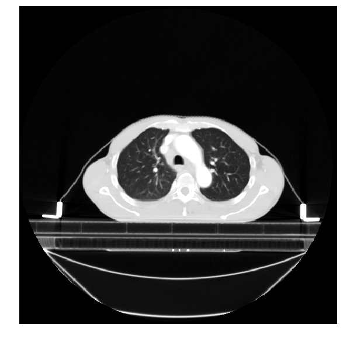

```python
# 1. 展示医学图像
import matplotlib.pyplot as plt
import matplotlib.image as mpimg

image = windowlize_image(image_raw, 1500, -500)[0]
image = npy_to_png(image)
image = (image - float(np.min(image))) / float(np.max(image)) * 255.

image = image[np.newaxis, :, :]
image = image.transpose((1, 2, 0)).astype('float32')
image = cv2.cvtColor(image, cv2.COLOR_GRAY2BGR)
cv2.imwrite('demo.png', image)
img = mpimg.imread('demo.png')
plt.figure(figsize=(10,10))
plt.imshow(img)
plt.axis('off')
plt.show()
```

```python
# 2. 进行肺部分割需要的前处理
lung_part, info_dict = preprocess_lung_part(image_raw, info_dict)
```

```
Begin to preprocess
data.min(), data.max() -1024 250
data.min(), data.max() 0.0 0.4212963
----------     begin crop2.5D     --------
----------     end crop2.5D     --------
```

```python
# 3. 进行病灶分割需要的前处理
ww, wc = (1500, -500)
lesion_part = windowlize_image(image_raw.copy(), ww, wc)
lesion_part = np.squeeze(lesion_part, 0)
```

```python
lesion_np_path = "lesion_part.npy"
lung_np_path = "lung_part.npy"
np.save(lung_np_path, lung_part)
np.save(lesion_np_path, lesion_part)
print('肺部分割输入：', lung_part.shape)
print('病灶分割输入：', lesion_part.shape)
```

```
肺部分割输入： (1, 320, 320, 3)
病灶分割输入： (512, 512)
```

## 二、加载预训练模型

PaddleHub提供了病灶分析和肺部分割的Module，即Pneumonia_CT_LKM_PP，包含病灶分割和肺部分割2个模块，都是基于UNet进行一系列优化。

```python
import paddlehub as hub

pneumonia = hub.Module(name="Pneumonia_CT_LKM_PP")
```

```
[2020-03-23 11:49:36,360] [    INFO] - Installing Pneumonia_CT_LKM_PP module
```

```
Downloading Pneumonia_CT_LKM_PP
[==================================================] 100.00%
Uncompress /home/aistudio/.paddlehub/tmp/tmpiad_bch0/Pneumonia_CT_LKM_PP
[==================================================] 100.00%
```

```
[2020-03-23 11:49:40,364] [    INFO] - Successfully installed Pneumonia_CT_LKM_PP-1.0.0
```

## 三、预测

PaddleHub对于支持一键预测的module，可以调用module的相应预测API，完成预测功能。

```python
input_dict = {"image_np_path": [[lesion_np_path, lung_np_path]] }

results = pneumonia.segmentation(data=input_dict)
```

```
[2020-03-23 11:49:45,049] [    INFO] - 0 pretrained paramaters loaded by PaddleHub
[2020-03-23 11:49:45,055] [    INFO] - Installing Pneumonia_CT_LKM_PP_lung module
```

```
Downloading Pneumonia_CT_LKM_PP_lung
[==================================================] 100.00%
Uncompress /home/aistudio/.paddlehub/tmp/tmp3pohjqws/Pneumonia_CT_LKM_PP_lung
[==================================================] 100.00%
```

```
[2020-03-23 11:49:48,510] [    INFO] - Successfully installed Pneumonia_CT_LKM_PP_lung-1.0.0
[2020-03-23 11:49:48,723] [    INFO] - 0 pretrained paramaters loaded by PaddleHub
```

```python
# 输出结果包含input_lesion_np_path与output_lesion_np
print(results[0])
```

```
{'input_lesion_np_path': 'lesion_part.npy', 'output_lesion_np': array([[0, 0, 0, ..., 0, 0, 0],
       [0, 0, 0, ..., 0, 0, 0],
       [0, 0, 0, ..., 0, 0, 0],
       ...,
       [0, 0, 0, ..., 0, 0, 0],
       [0, 0, 0, ..., 0, 0, 0],
       [0, 0, 0, ..., 0, 0, 0]], dtype=int64), 'output_lung_np': array([[0, 0, 0, ..., 0, 0, 0],
       [0, 0, 0, ..., 0, 0, 0],
       [0, 0, 0, ..., 0, 0, 0],
       ...,
       [0, 0, 0, ..., 0, 0, 0],
       [0, 0, 0, ..., 0, 0, 0],
       [0, 0, 0, ..., 0, 0, 0]]), 'input_lung_np_path': 'lung_part.npy'}
```

以上运行结果中：

**input_lesion_np_path**：存放用于病灶分析的numpy数组路径

**output_lesion_np**：存放病灶分析结果

**output_lung_np**：存放肺部分割结果